# Red Wine Data Exploration by Elias Paz

# Introduction:

I will be exploring the Red Wine Quality data set. This data contains data from 11 different variables that help determine the quality of a red wine.

# Questions

In exploring this data set, I will seek to answer the following questions:  
1. What does the Quality of Wine distribution look like?  
2. What properties and their respective values make up a good wine?  
3. What properties and their respective values make up a defective wine?  
# Univariate Plots Section

```
## 'data.frame':    1599 obs. of  13 variables:
##  $ X                   : int  1 2 3 4 5 6 7 8 9 10 ...
##  $ fixed.acidity       : num  7.4 7.8 7.8 11.2 7.4 7.4 7.9 7.3 7.8 7.5 ...
##  $ volatile.acidity    : num  0.7 0.88 0.76 0.28 0.7 0.66 0.6 0.65 0.58 0.5 ...
##  $ citric.acid         : num  0 0 0.04 0.56 0 0 0.06 0 0.02 0.36 ...
##  $ residual.sugar      : num  1.9 2.6 2.3 1.9 1.9 1.8 1.6 1.2 2 6.1 ...
##  $ chlorides           : num  0.076 0.098 0.092 0.075 0.076 0.075 0.069 0.065 0.073 0.071 ...
##  $ free.sulfur.dioxide : num  11 25 15 17 11 13 15 15 9 17 ...
##  $ total.sulfur.dioxide: num  34 67 54 60 34 40 59 21 18 102 ...
##  $ density             : num  0.998 0.997 0.997 0.998 0.998 ...
##  $ pH                  : num  3.51 3.2 3.26 3.16 3.51 3.51 3.3 3.39 3.36 3.35 ...
##  $ sulphates           : num  0.56 0.68 0.65 0.58 0.56 0.56 0.46 0.47 0.57 0.8 ...
##  $ alcohol             : num  9.4 9.8 9.8 9.8 9.4 9.4 9.4 10 9.5 10.5 ...
##  $ quality             : int  5 5 5 6 5 5 5 7 7 5 ...
```

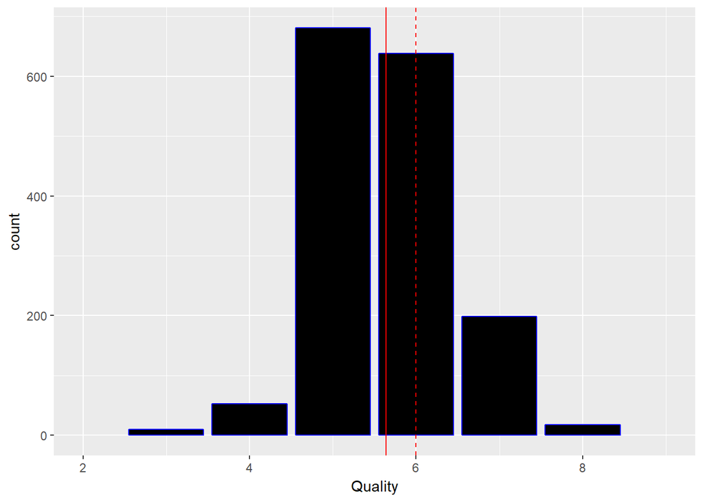

The first categorical variable I wanted to explore was the Quality. From the graph above, it looks like majority of wines are above the mean of 5.636 which is displayed in the solid red line. The median is the stripped line.

```
##
##   3   4   5   6   7   8
##  10  53 681 638 199  18
```

```
##
##    low medium   high
##     63   1319    217
```

```
##    Min. 1st Qu.  Median    Mean 3rd Qu.    Max.
##   3.000   5.000   6.000   5.636   6.000   8.000
```

```
## [1] 744
```

```
## [1] 855
```

From the tables and summaries above, Wine Rankings of 5 and 6 are the most popular rankings. The table also confirms that there are more rankings above the mean than below.  
I wonder what the alcohol percentage distribution looks like.

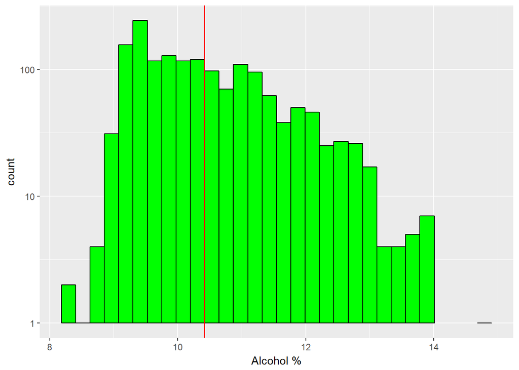

From the graph above, it looks like most wines samples had an alcohol percentage of about 9-10.5%. There are a few outliers present above 14%

I wonder what other variables such as pH and the different acids look like.

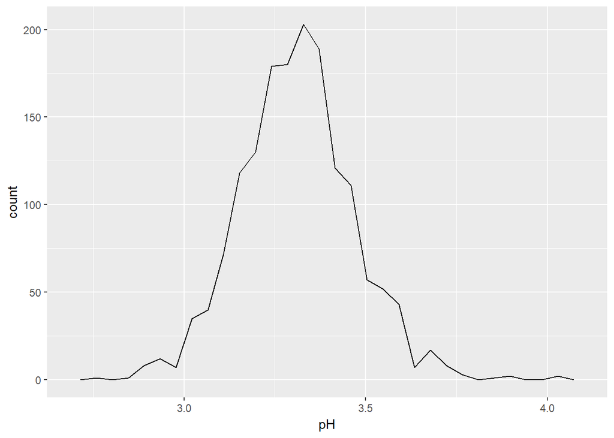

As stated in the data set explanation, most wines have a pH between 3 and 4 and that is evident in the graph above.  
It is said that pH represents how much acid is in a wine regardless of taste.  
Next lets see the total acidity, tritratable acid, of the sampled wines.

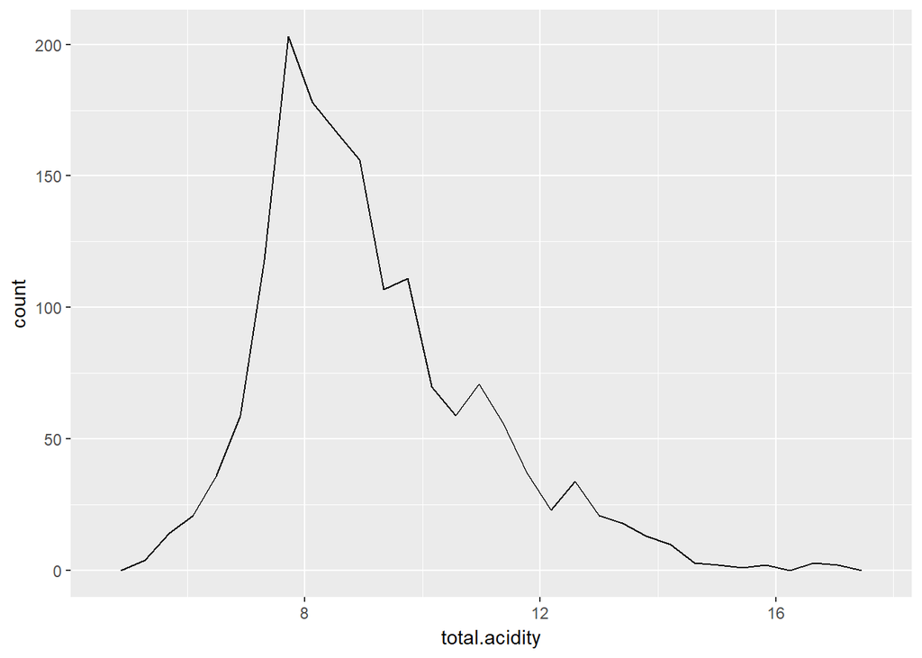

```
##    Min. 1st Qu.  Median    Mean 3rd Qu.    Max.
##   5.270   7.827   8.720   9.118  10.070  17.045
```

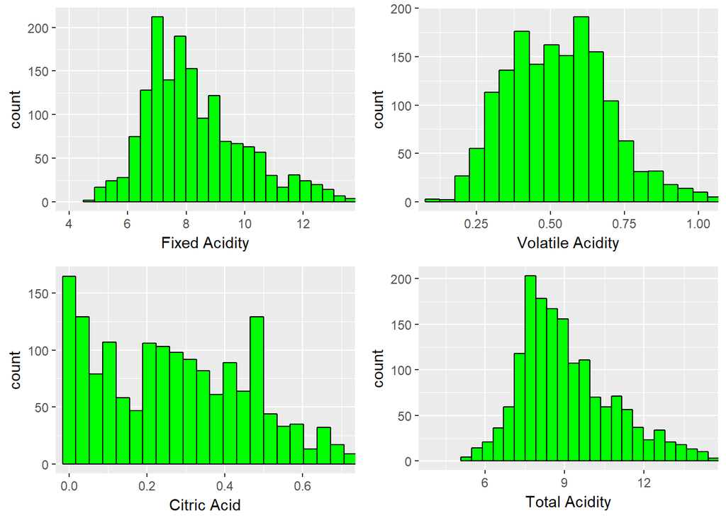

First is fixed acidity

```
##      nbr.val     nbr.null       nbr.na          min          max
##     1599.000        0.000        0.000        4.600       15.900
##        range          sum       median         mean      SE.mean
##       11.300    13303.100        7.900        8.320        0.044
## CI.mean.0.95          var      std.dev     coef.var
##        0.085        3.031        1.741        0.209
```

From the table above, it appears there are outliers in the data. The max value of 15.9 g/ml is more than 3 STDs from the mean  
Next is volatile acidity

```
##      nbr.val     nbr.null       nbr.na          min          max
##    1599.0000       0.0000       0.0000       0.1200       1.5800
##        range          sum       median         mean      SE.mean
##       1.4600     843.9850       0.5200       0.5278       0.0045
## CI.mean.0.95          var      std.dev     coef.var
##       0.0088       0.0321       0.1791       0.3392
```

From the table above, it appears there are outliers in the data. The max value of 1.58 g/ml is more than 3 STDs from the mean  
Next is citric acid

```
##      nbr.val     nbr.null       nbr.na          min          max
##    1599.0000     132.0000       0.0000       0.0000       1.0000
##        range          sum       median         mean      SE.mean
##       1.0000     433.2900       0.2600       0.2710       0.0049
## CI.mean.0.95          var      std.dev     coef.var
##       0.0096       0.0379       0.1948       0.7189
```

From the table above, it appears there are outliers in the data . The max value of 1 g/ml is more than 3 STDs from the mean.  
The last one is Total Acidity

```
##      nbr.val     nbr.null       nbr.na          min          max
##     1599.000        0.000        0.000        5.270       17.045
##        range          sum       median         mean      SE.mean
##       11.775    14580.375        8.720        9.118        0.046
## CI.mean.0.95          var      std.dev     coef.var
##        0.090        3.359        1.833        0.201
```

From the table above, it appears there are outliers in the data as the graph suggests. The max value of 17.045 g/ml is more than 3 STDs  
from the mean

Now lets take a look at the distribution for sulphates

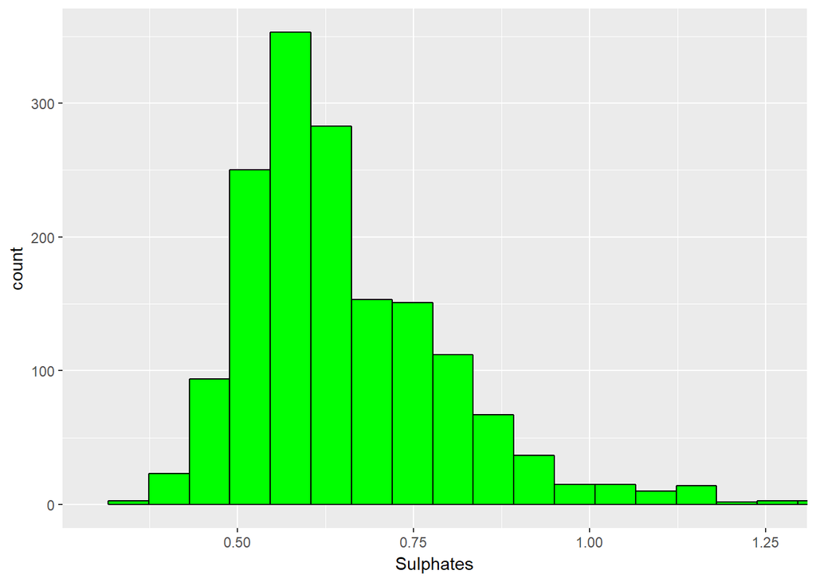

Sulphates has a normal distribution between about 0 and 1 g/ml and appear to have outliers above 1.5 g/ml Top 1% have been omitted  
from graph  
Lets looks at some descriptive statistics for sulphates.

```
##      nbr.val     nbr.null       nbr.na          min          max
##    1599.0000       0.0000       0.0000       0.3300       2.0000
##        range          sum       median         mean      SE.mean
##       1.6700    1052.3800       0.6200       0.6581       0.0042
## CI.mean.0.95          var      std.dev     coef.var
##       0.0083       0.0287       0.1695       0.2576
```

From the table above, it appears there are outliers in the data as the graph suggests. The max value of 2 g/ml is more than 3 STDs  
from the mean

# Univariate Analysis

### Structure of data set:

The data set contains 1599 observations with 13 different variables.  
‘data.frame’: 1599 obs. of 13 variables:

### Main Feature of interest:

The main feature I am interested in from this data set is how wine quality is affected.

### Other features in the dataset that will help support investigation into feature of interest?

I will explore the correlation of wine quality with the other variables to help determine the other features I will use to support my  
investigation.

### New Variables created:

The following new variables were created to help aid my data exploration in the bivariate and multivariate sections.

- df$Quality_Buckets
- df$total.acidity

### Features Explored

- Wine Quality  
  The wine Quality distribution looks like a normal distrubtion with a mean of 5.64. Majority  
  of the Quality rankings where above the mean. There were 855 entries above the mean and  
  744 entries below the mean. The actual distribution of quality rankings can be seen below.

```
##
##   3   4   5   6   7   8
##  10  53 681 638 199  18
```

- Acidity  
  There are two different types of acidity in wine, Fixed Acidity and Volatile Acidity. Volatile Acidity contributes to the overall taste  
  of wine while non volatile wine can create a unpleasent vinegar taste with high quantities. The distributions for for fixed acidity and  
  total acidity seem to be normal distrubtions while citric and volatile acidity look more bi-modal. From the graphs and tables for acidity,  
  there are outliers present in every acidity category. To deal with the outliers, the best metric to explore is the median since it is  
  more robust to outliers.
- Sulphates  
  From the summary tables for sulphates, we see that sulphates have a a min of .33 g/ml and a max of 2 g/ml. The mean for sulphates is .66 g/ml.  
  It appears that the max value for sulphates is an outlier due to it being over 3 STDs from the mean. There are are 964 wine rankings with  
  sulphate levels below the mean and 635 rankings above the mean. In comparison, there are are 770 rankings above the median and  
  768 rankings below the median. It appears the metric to best explore is the median to help deal with outliers that are present in the data.

# Bivariate Plots Section

Before I begin the Bivariate exploration, I am going to load in the data set again and create factors out of the quality rankings  
to help with the supporting graphs. I will also add the total acidity variable in to the data frame to perform correlations against wine quality rankings  
To start my exploration, I will first create a correlation matrix to identify the top strongest correlated properties to wine quality

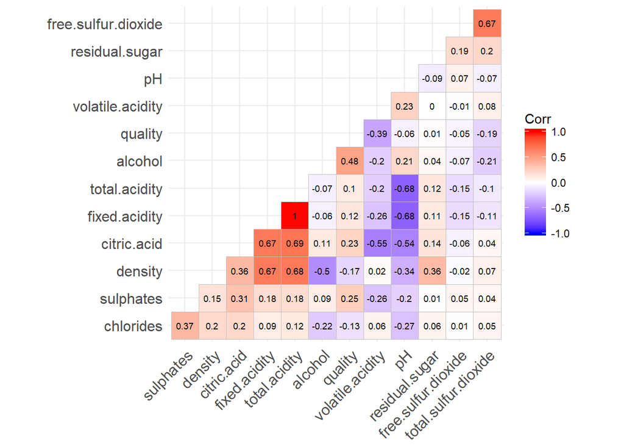

From the correlation matrix for quality, I will explore the top 3 positive correlations to see the effect on quality. Those are:  
1. Alcohol  
2. Sulphates  
3. Citric acid

I am also interested in exploring the largest negative correlation to see what the effect on quality is. The variable I will look at is  
1. Volatile Acidity

### Alcohol Exploration

To start off, lets explore how the alcohol percentage is distributed accross wine quality to try and get an understanding of how  
alcohol relates to high quality wines

```
## # A tibble: 6 x 4
##   quality Alcohol_Mean Alcohol_Median     n
##     <int>        <dbl>          <dbl> <int>
## 1       3         10.0            9.9    10
## 2       4         10.3           10.0    53
## 3       5          9.9            9.7   681
## 4       6         10.6           10.5   638
## 5       7         11.5           11.5   199
## 6       8         12.1           12.2    18
```

As stated earlier in the univariate section, the mean wine quality was about 5.6% and there were more entries above the mean then below. In the summary table above, it appears that as wine quality rankings above 5 increase, so does the alcohol mean.

Now lets see how this looks like visually on a box plot

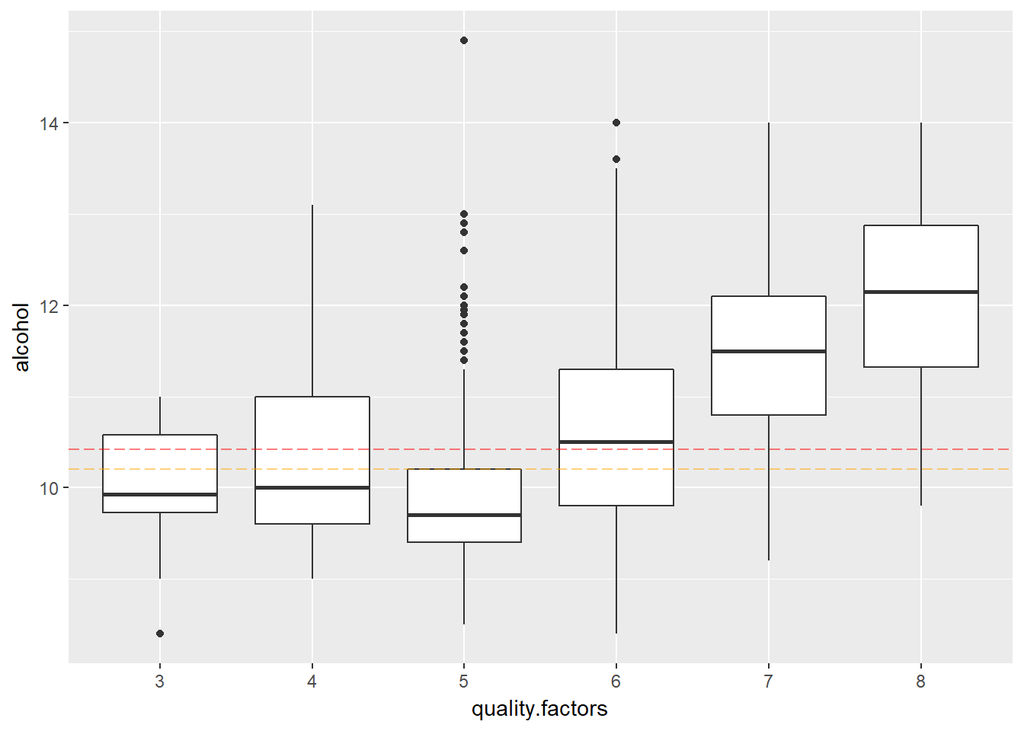

As seen above, the boxplot confirms that as the quality increases beyond the quality mean, the mean of alcohol seems to increase as well.  
The red dotted line represents the mean for alcohol and the yellow dotted line represents the median.  
When we graph the alcohol means, we can see a similar pattern with the median as well. See graph below

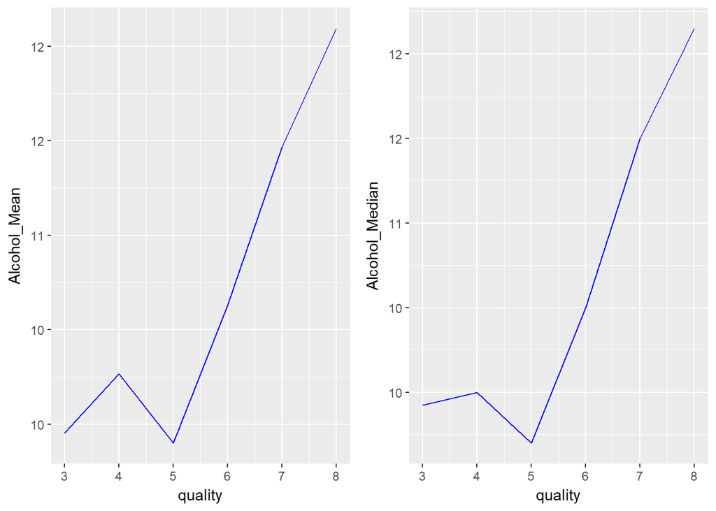

As seen above, as the Wine quality increases, the alcohol percentage mean and medians increase as well at around a ranking of 5.

Lets see how this looks on a scatter plot.

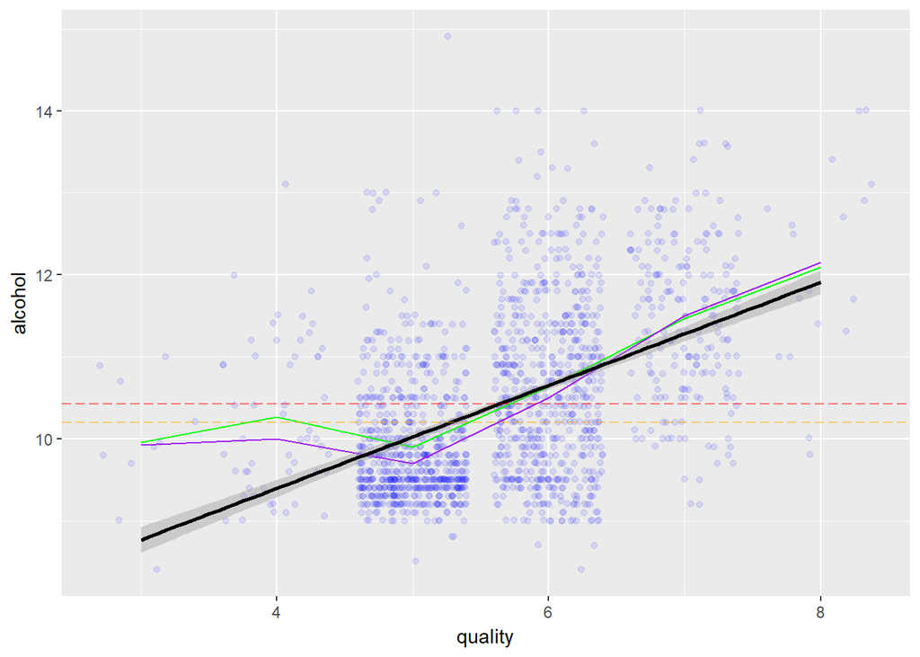

From the scatter plot, we can see that majority of the high quality wines have alcohol percentages that are above the mean and medians.  
In contrast, we see majority of the lower quality wines have alcohol percentages below the mean and medians.

### Sulphates Exploration

The next wine property I will explore is sulphates and see how it relates to wine quality rankings. Lets remember that sulphates  
are not as strongly correlated to quality as alcohol.  
To start off, lets explore how sulphates is distributed accross wine quality to try and get an understanding of how sulphates relate  
to high quality wines.

```
## # A tibble: 6 x 4
##   quality sulphates_mean sulphates_median     n
##     <int>          <dbl>            <dbl> <int>
## 1       3           0.57             0.54    10
## 2       4           0.60             0.56    53
## 3       5           0.62             0.58   681
## 4       6           0.68             0.64   638
## 5       7           0.74             0.74   199
## 6       8           0.77             0.74    18
```

As stated in the univariate analysis, the metric I will explore is the median to deal with the outliers. Sulphates  
have a median of .62 g/ml. It appears that as wine quality rankings increase, sulphate levels also increase.  
Lets looks at this visually.

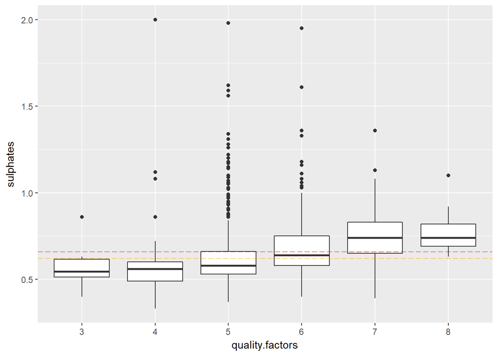

As seen above in the box plot, it appears higher quality wines have higher levels of sulphates that are  
above the mean and median. Lets see how the median levels look like.

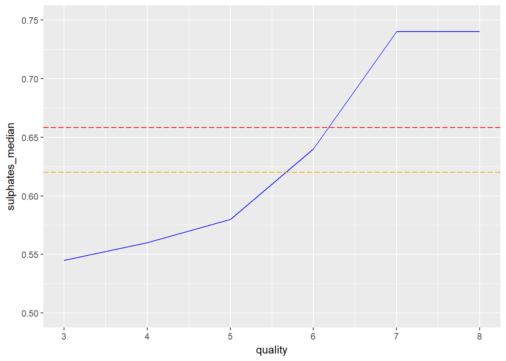

The graph above confirms our obversations seem in the tables that as the wine quality increases, the sulphates levels increase.  
It appears that the high quality wines contain a sulphate level that is above both the median and mean levels.  
The yellow dotted line is the median and the red dotted line is the mean.  
Lets see how this looks on a scatterplot

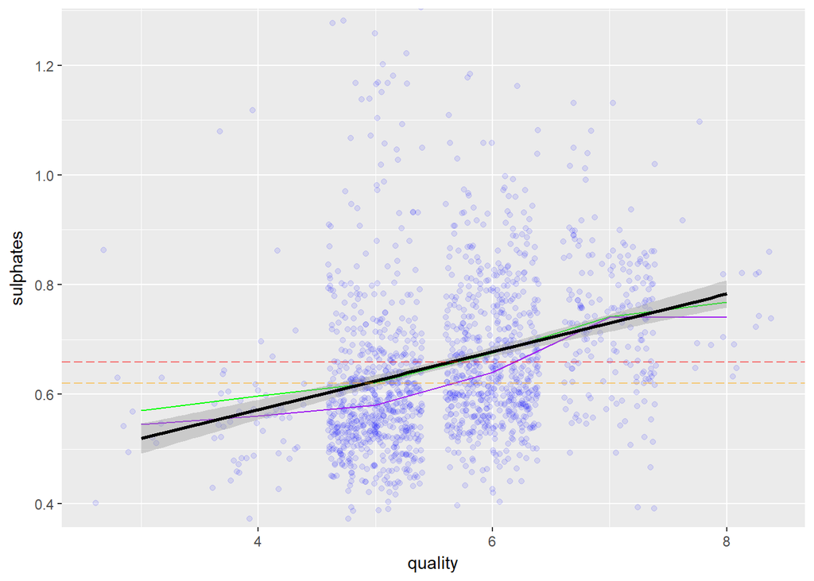

From the scatter plot, the top 1% have been omitted to deal with outliers and we can see that there are  
fewer high quality wines with sulphate levels below the mean and median than above it.  
Additionally we can see that there are more lower quality wines that have sulphate levels below the mean and median levels than above.

### Citric Acid Exploration

Moving on from the sulphates exploration, I am now going to explore how citric acid relates to wine quality rankings.  
First, lets remember that citric acid is not as strongly correlated to quality as alcohol percentage.

To start off, lets explore how citric acid is distributed accross wine quality to try and get an understanding of how citric acid relates  
to high quality wines.

```
## # A tibble: 6 x 4
##   quality citric_acid_mean citric_acid_median     n
##     <int>            <dbl>              <dbl> <int>
## 1       3             0.17              0.035    10
## 2       4             0.17              0.090    53
## 3       5             0.24              0.230   681
## 4       6             0.27              0.260   638
## 5       7             0.38              0.400   199
## 6       8             0.39              0.420    18
```

In the case for citric acid, it looks like it follows a similar behaviour as sulphates.  
As stated in the univariate analysis, the metric I will explore is the median to deal with the outliers. There seems to be more  
outliers in citric acid with the big difference in the means and medians found in the lower quality wines. The median for citric acid  
is .26 g/ml. An interesting obervation is that there are more citric acid levels below both the mean and median in contrast to sulphates.  
Lets looks at this visually.

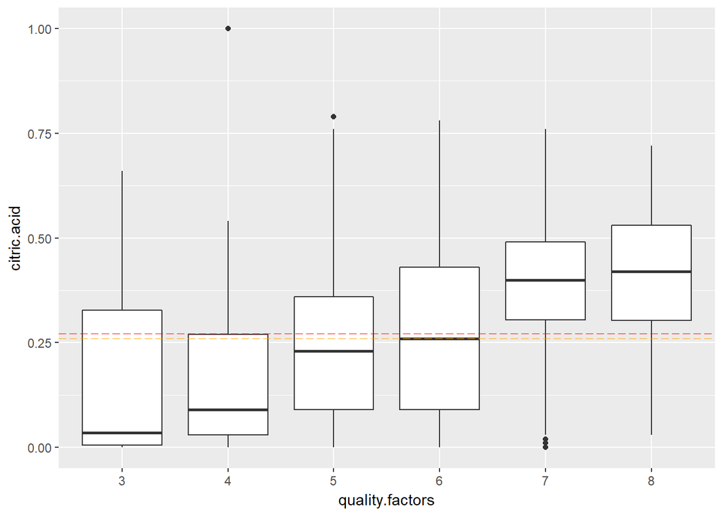

The box plot above confirms the obersvations made from the median table. It appears the higher quality wines with rankings of 7 and 8  
have citric acid levels above the mean and the median.  
Lets take a visual look at the medians for citric acid across the different wine quality rankings.

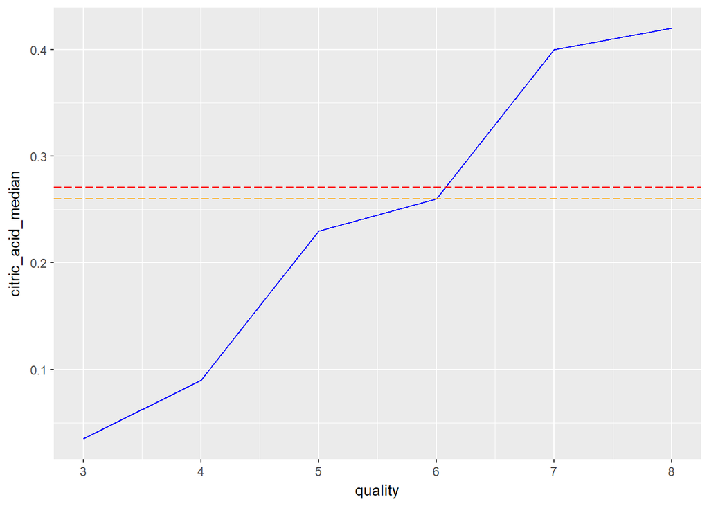

The graph above also confirms the observation that as wine quality increases, citric acid levels incease as well. Additionally,  
similar to sulphates, high quality wines have citric acid levels that are above both the mean and medians

Finally, lets take a look at a scatter plot

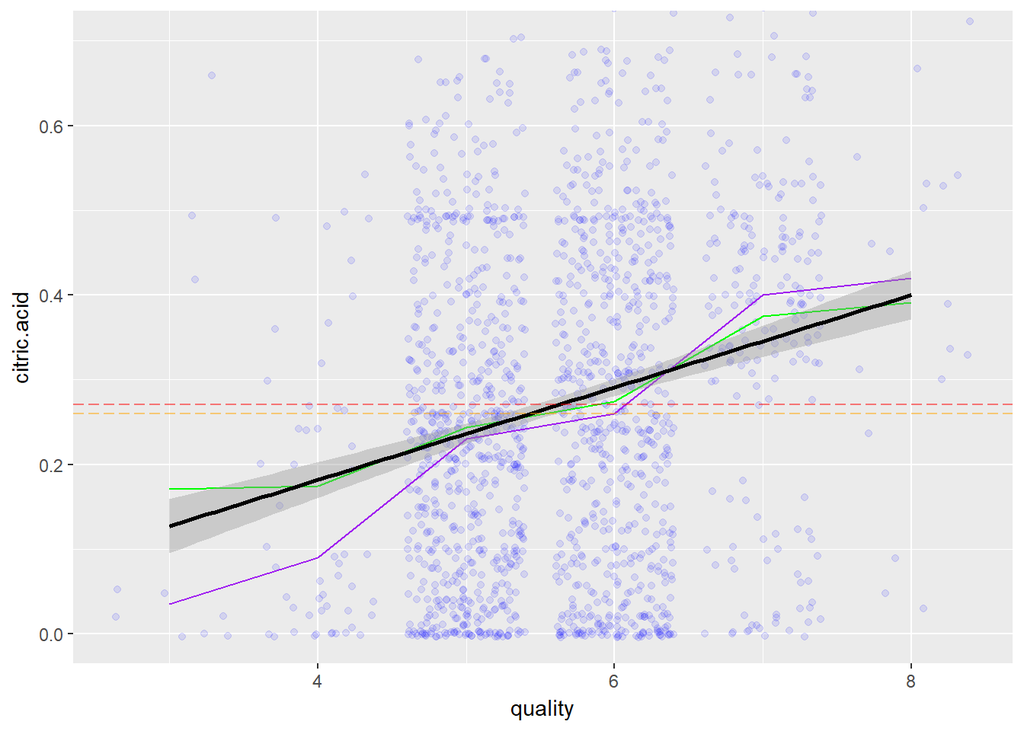

From the scatter plot, the top 1% have been omitted to deal with outliers. We can see that majority of the high quality wines  
have citric levels above the mean and median. However, we can also see that there are more lower quality wines  
that are above the mean and median as well. This shows that citric acid is not very strongly correlated to quality.

### Volatile Acidity

Now that we have a better idea of the properties that make a good wine, lets explore a property that makes a bad wine.  
First, lets remember that volatile acidity is negatively correlated to quality.  
To start off, lets explore how volatile acidity is distributed accross wine quality to try and get an understanding of how volatile acidity relates to wine quality.

```
## # A tibble: 6 x 4
##   quality volatile_acidity_mean volatile_acidity_median     n
##     <int>                 <dbl>                   <dbl> <int>
## 1       3                  0.88                    0.84    10
## 2       4                  0.69                    0.67    53
## 3       5                  0.58                    0.58   681
## 4       6                  0.50                    0.49   638
## 5       7                  0.40                    0.37   199
## 6       8                  0.42                    0.37    18
```

As stated in the bivariate anaylsis, i will be exploring the median metric to deal with outliers in the data.  
Looking at the mean/median table above, it is interesting to note that as the wine quality increases, volatile acidity levels decrease.  
This has to do with the negative correlation.  
Lets see how this looks visually.

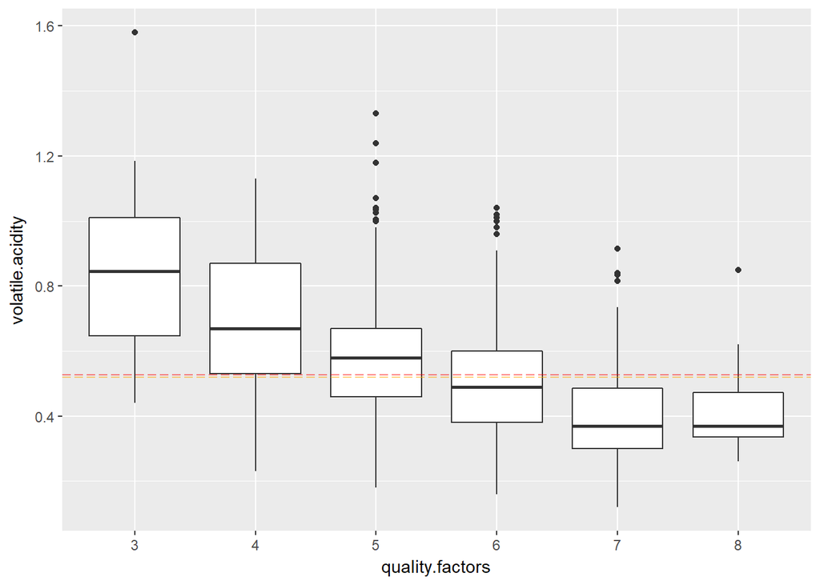

The box plot above seems to support our observation that the lowest quality wines contain the most volatile acidity levels. It is  
important to note that those levels are above the mean and median. The high quality wines have volatile acidity levels well below the  
mean and medians.  
Lets take a look at the medians from each wine ranking.

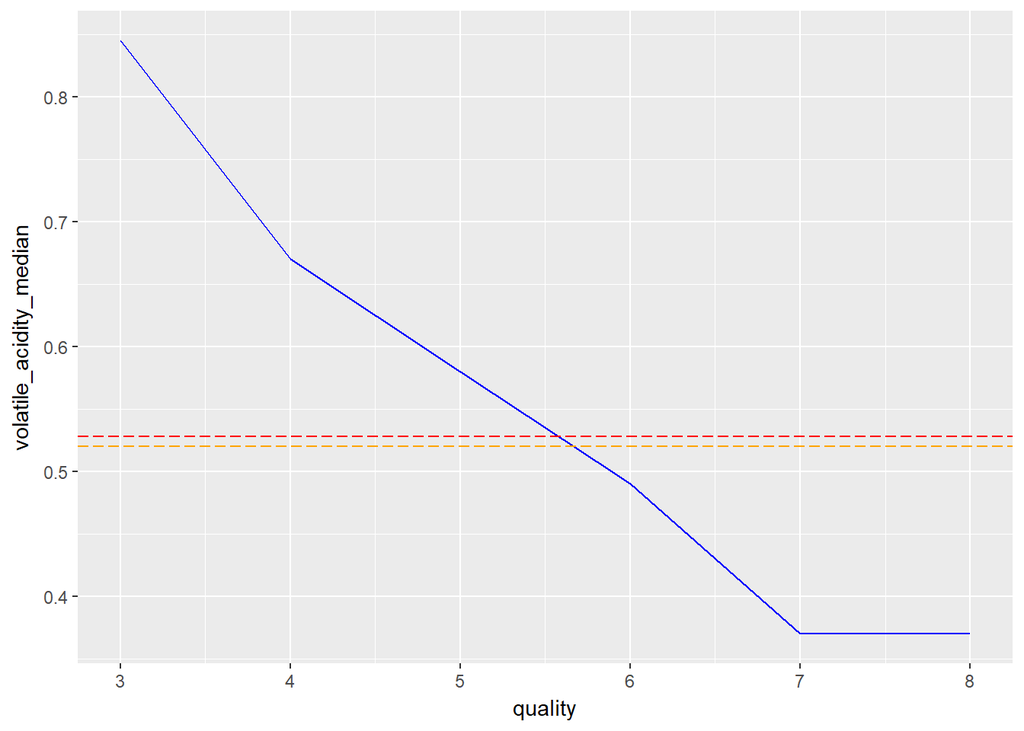

Again, we can see that the lower quality wines have medians that are significantly higer than the higher quality wines.  
Finally lets take a look at a scatter plot.

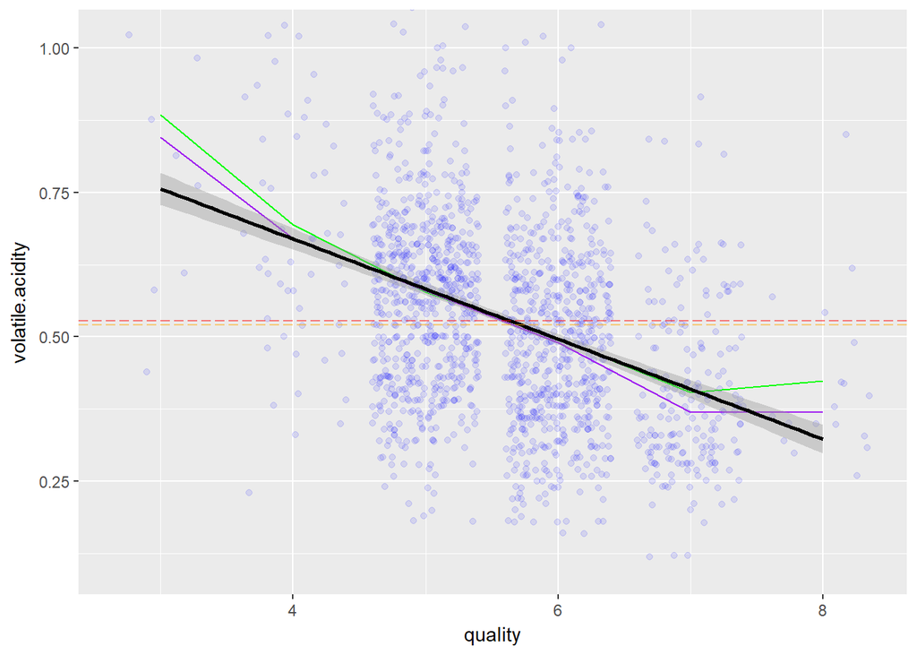

From the scatter plot, we see that there are very few low quality wines with volatile acidity levels that are below the mean and median levels  
Conversly, we see that there are few high quality wines that have volatile acidity levels above the mean and median levels.

# Bivariate Analysis

My eploration consited of how different properties affect overal wine quality.  
### Alcohol Percentage vs Quality  
The alcohol percentage had the strongest relationship to wine quality than any other property with a co-efficient value of .48.  
I discovered that as the alcohol percentage increased, the wine quality seemed to increase. The higher quality wines rated 7 and 8  
had much higher alcohol means and medians than the lower quality wines. As seen from the scatter plot, there are more high quality wines  
that have alcohol percentages above the alcohol means and medians than below it.

### Sulphate levels vs Quality

The correlation between sulphate and quality was the 2nd strongest relationship that carried a co-efficient of .25.  
Sulphate seemed to experience a similar pattern as the alcohol percentage did. As wine quality increased, sulphate levels increased.  
The higher quality wines had higher sulphate means and medians than the lower quality wines. As seen from the scatter plot, there are  
very few high quality wines that have sulphate levels below the mean and medians. However, due to the weaker relationship, there appears  
to be a good amount of lower quality wines that are above the mean and median sulphate levels.

### Citric Acid levels vs Quality

The correlation between citric acid and quality was the 3rd strongest relationship that carried a co-efficient of .23.  
Citric Acid has a similar relationship to sulphates and alcohol. As the wine quality increased, the citric acid means and medians  
increased as well. Majority of the high quality wines had citric acid levels above the mean and median levels. Similar to sulphates and  
due to the weaker relationship on quality, there were a good amount of lower quality wines above the mean and median levels.

### Volatile Acidity vs Quality

My last exploration was on Volatile acidity vs Quality. This relationship had the strongest negative relationship with a co-efficient  
of -.39. It was interesting to see that volatile acidity had an opposite affect on quality. As volatile acidity decreased, wine quality  
increased as suggested by the correlation relationship. As the wine quality increased, the volatile acidity mean and median levels  
decreased. As seen in the scatter plot there are very few high quality wines that have volatile acidity levels above the mean and median  
levels. This makes sense because high volatile acidity levels leads to an unpleasant taste in wine.

# Multivariate Plots Section

In the Bivariate section, we saw how quality was affected by alcohol percentage,citric acid, sulphates, and volatile acidity.  
I am now going to explore the relationship between these properties across the different quality buckets.  
All graphs will contain data in the 1-99% quantile range to omit any outliers in the data and will be split into 4 quandrants by the means  
and medians from each property explored.

The first relationship I will explore is alcohol vs citric acid.

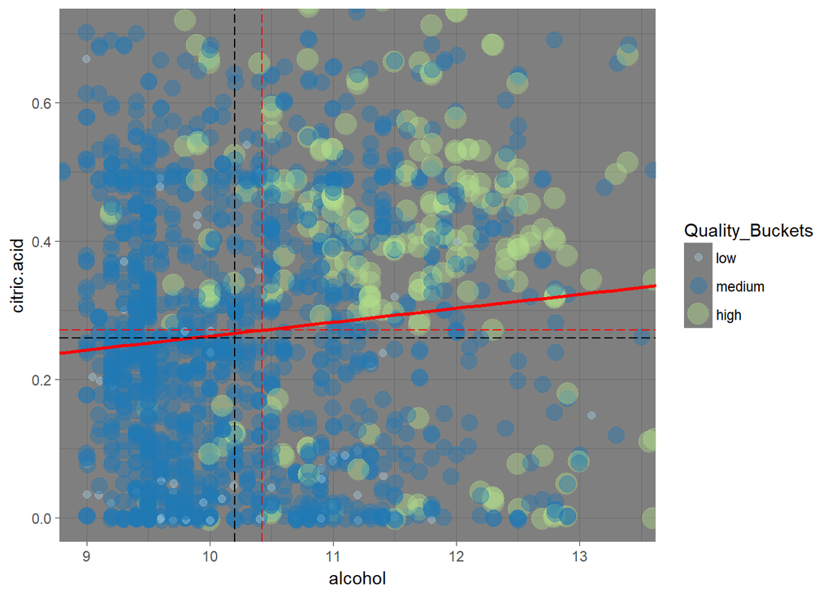

In the graph above, the wine quality rankings were grouped into 3 different groups.  
* 3-4 = Low  
* 5-6 = Medium  
* 7-8 = High

We can see that the majority of the high quality wines are above the means and medians of the alcohol percentage and citric acid levels.  
It appears that the highest quality wines of 7 and 8, have a combination of citric acid levels of at least  
0.26g/ml and alcohol percentage of 10.2%

Next I would like explore the relation between sulphate and citric acid across the different wine qualities. As seen in the correlation  
table in the bivariate section, sulphate and citric acid have a correlation co-efficient of .31 and we already saw that these two  
properties have an affect on quality.

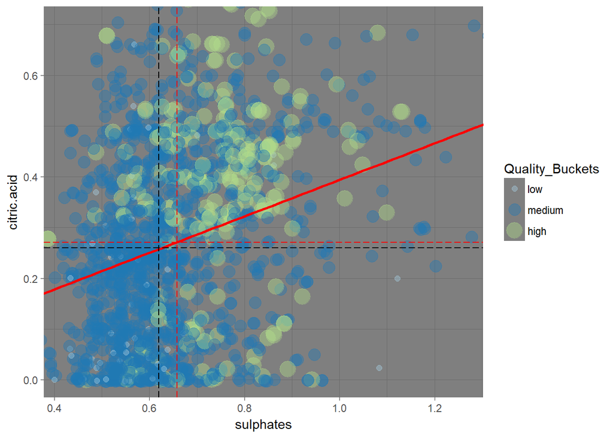

The graph above tells a very similar story when we graphed alcohol vs citric acid across the different quality buckets. It appears that  
majority of wines ranked 7 or 8 have a combination of sulphate levels that are at least 0.62g/ml and  
citric acid levels of at least 0.26 g/ml.

The next relation I will look at is alcohol vs sulphates and explore the relation to quality.

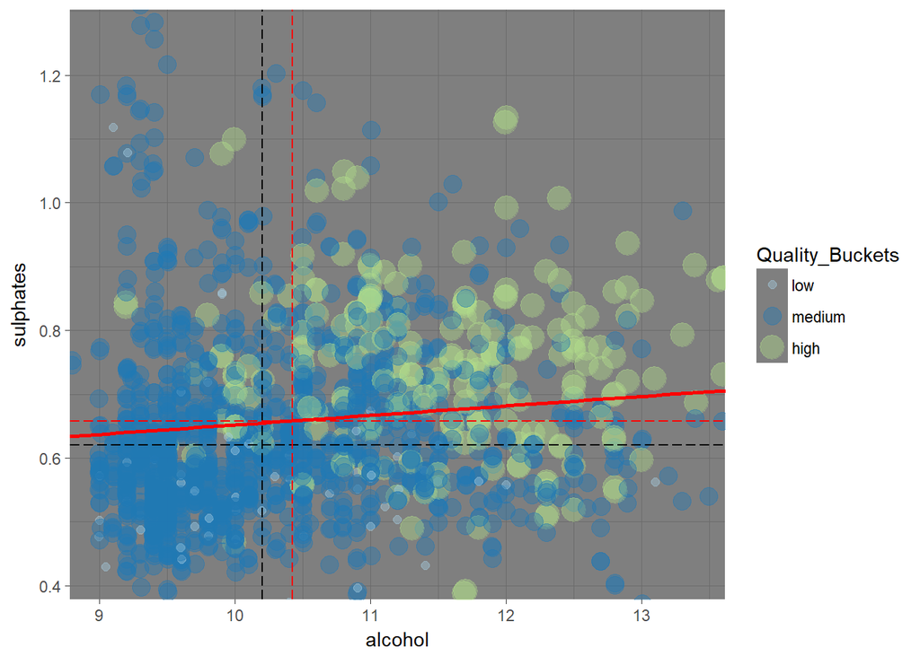

In this third graph, we begin to see a consistent pattern in the top 3 positively correlated properties on quality. The top wines rated  
7 and 8 have a combination of alochol percentage of at least 10.2% and sulphate levels of 0.62 g/ml.  
Both levels are above their respective medians.  
Now I am going to explore the combination of Volatile Acidy with alcohol,citric acid,and sulphates to see the effect on quality.  
I’ll start with alcohol vs Volatile acidity.

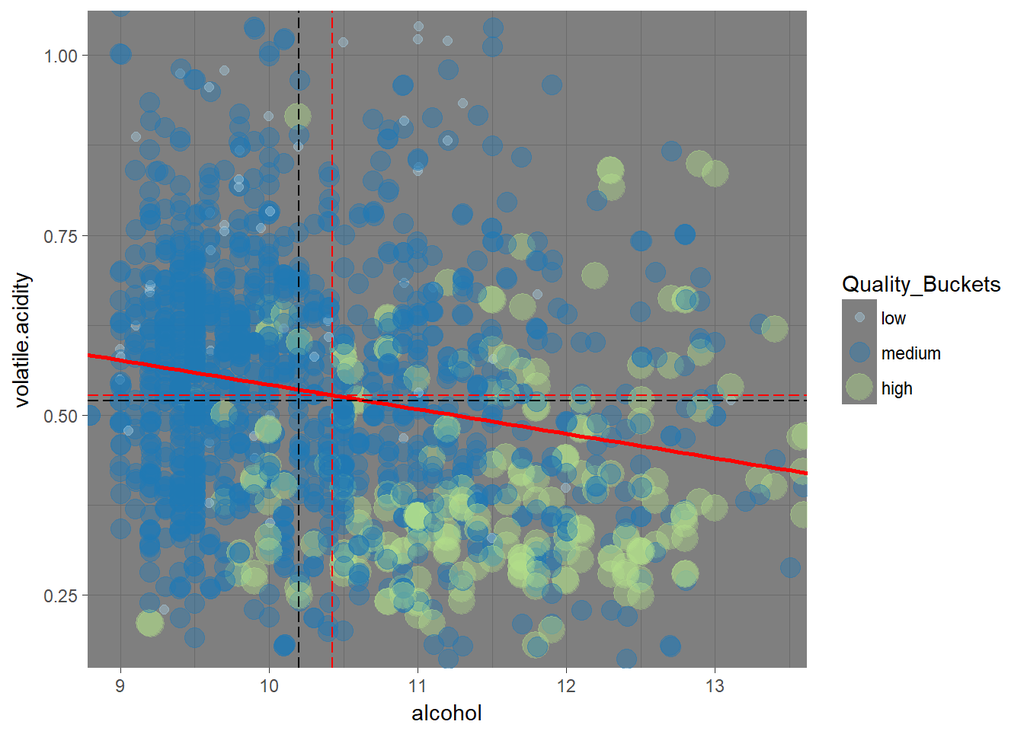

We can clearly see that majority of the wines rated 7 and 8 have an alcohol percentage of at least 10.2% and  
have volatile acidity levels less than 0.52 g/ml  
Next up is citric acid vs volatile acid.

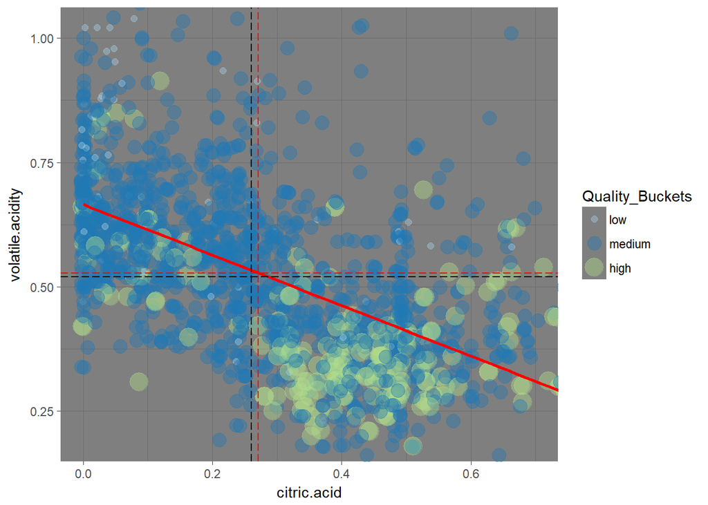

In the graph above, we see majority of the wines rated between 7 and 8 are all in the lower right quadrant of the graph which is very similar  
to the alcohol vs volatile acidity graph. We see that majority of these wines have no more than 0.52 g/ml  
of volatile acidity and at least 0.26 g/ml of citric acid.  
The final reltionship I’ll explore is volatile acidity vs sulphates.

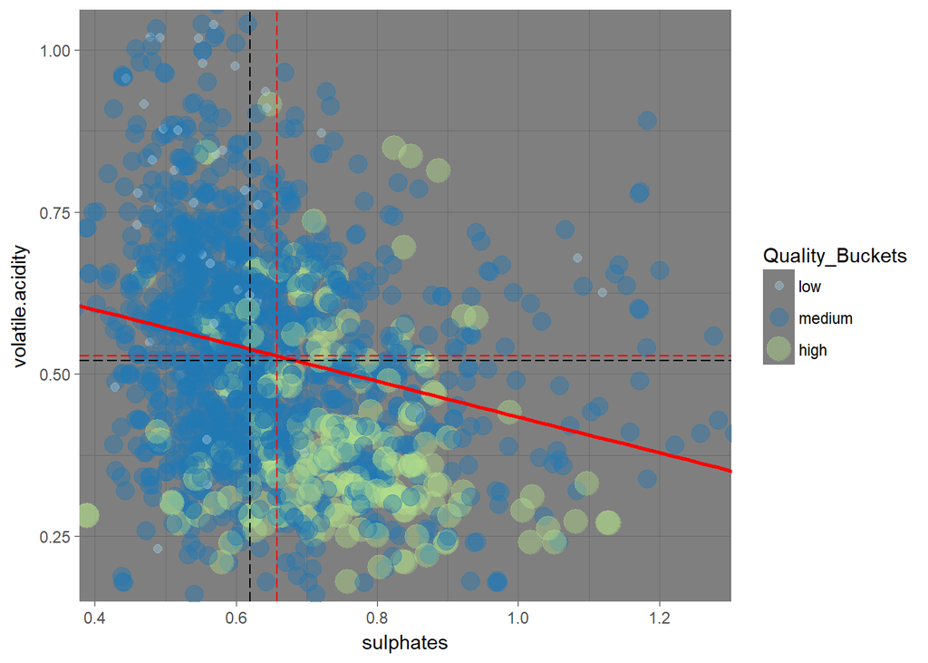

From the Final graph above, we can see the same pattern from the previous 2 graphs. Majority of the high quality wines are in the bottom  
right quandrant of the graph. High quality wines have no more than 0.52 g/ml  
of volatile acidity and at least 0.62 g/ml of sulphates.

# Multivariate Analysis

After exploring the combination affects of alcohol,citric acid,sulphates,and volatile acidity on quality, some interesting observations can  
be seen.  
1. As seen in the bivariate section, alcohol,citric acid,and sulphates are all positively correlated to Quality. This relationship shows up  
in the multivariate plots. When you graph the combination affect of these properties, one can notice that majority of high quality wines  
are in the upper right quadrant and above the means and medians for each respective property. However, The combination affect of these properties are not as strong for the medium and low quality wines as they are spread across all the quandrants of the graphs.  
2. As seen in the bivariate section, volatile acidity was negatively correlated to quality and to the other properties I mentioned earlier.  
When you graph the combination affect of volatile acidity with the other 3 properties across the quality buckets, you can see this relationship  
in the high quality wines. Majority of the high quality wines are in the lower right quadrants of the graph and had volatile acidity levels  
below the median of volatile acidity. However, this also is not true for the medium and low quality wines. It appears the high quality wines  
are most affected by this correlation relationship.

# Final Plots and Summary

### Plot One

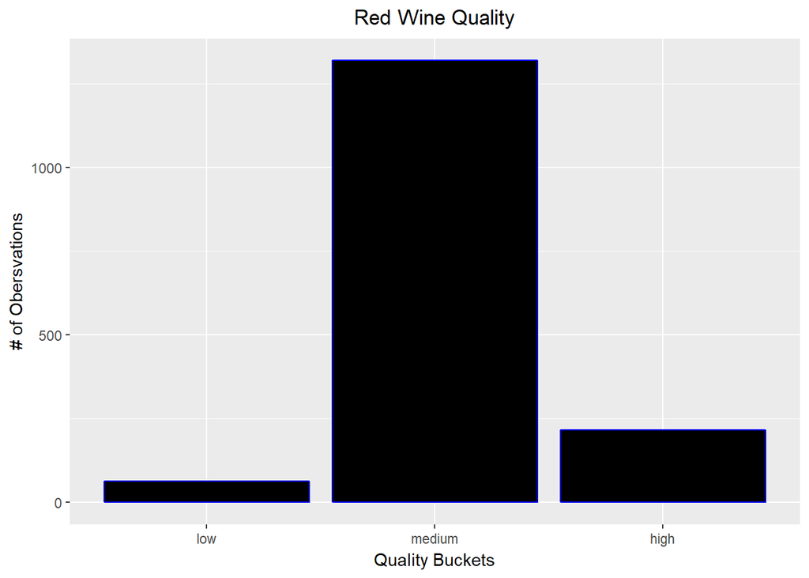

### Description One

Getting back to the original question of the properties that make a good wine, we first need to know what the  
distribution for Quality rankings look like to get a feeling of what are the most common rankings and the least common rankings.  
As seen from plot one, the most common wine rankings are between 5-6 which comprise of a medium bucket ranking. The least common ranking  
is 3-4 which comprises the low bucket.

### Plot Two

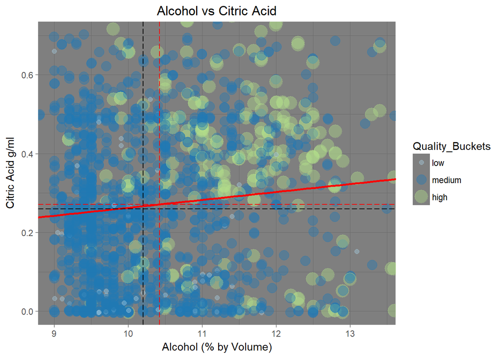

### Plot Three

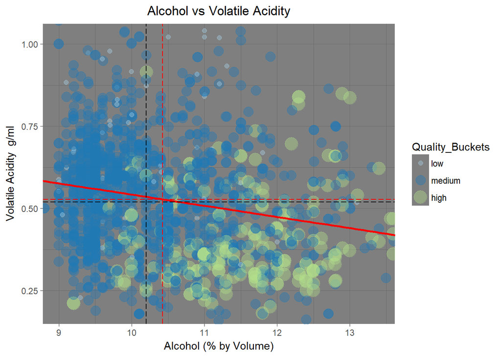

### Description Three

In the bivariate section, we also saw that Volatile Acidity was the strongest negatively corrleated property to Quality rankings.  
In the graph above, the dashed lines are the medians and means for Alcohol and Volatile Acidity. They essentially cut the graph  
into 4 quadrants. When you graph Alcohol vs Volatile Acidity across the different quality buckets, you can see that majority of the higher quality wines are in the lower right quadrant which means that Alcohol percentage is above the mean and median and  
Volatile acidity levels are below its mean and median. The bottom and top 1 % have been omitted to remove any outliers from the graph. This graph helps us answer what properites can contribute to a low quality wine.

# Reflection

The Red Wine Data set that I explored contained 1599 obvservations of wine properties and quality outputs. In this exploration, I attempted to answer the following questions:  
1. What does the Quality of Wine distribution look like?  
2. What properties and their respective values make up a good wine?  
3. What properties and their respective values make up a defective wine?

Upon reflecting on these questions and the explorations I conducted, I can now answer these questions:  
1. The distribution for Quality is a normal distribution with a mean of 5.636  
2. It appears that the combination of Alcohol percentage, Citric Acid levels and Sulphates levels all contribute to a good quality wine.  
I found that the levels for each of these properites were above the medians for each respective property.  
3. It appears that Volatile Acidity is the main property that contributes to a defective wine. High levels of Volatile Acidity are more  
common with the low and median ranked wines. It is very rare to find high levels of Volatile Acidity in High Quality wines.